# Basic SBM

2023-09-27

Basic SBM with NIMBLE This version has high within block connectivity Exercise ideas: - Start without within/between pattern and very few nodes for ease of visualizing the graph - Add more nodes and change the connectivity pattern - Add prior for alpha - Intuition building for the Dirichlet, how to set alpha - Perform sbm on real data - how important is alpha? do we want different within and between patterns?

# TO DO:

- Figure out other other nimble plotting stuff - give more explanation for intro lab
- Add example and plot clusters vs region
- Look at Trace, WAIC, etc and come up with relevant questions
- Prior on number of clusters?
- Think more about theta prior

# PART 1: SIMULATE FROM AND FIT A BASIC STOCHASTIC BLOCK MODEL

## 1a. Simulate from a stochastic block model

First we simulate from a general stochastic block model with no constraints on between versus within block connectivity.

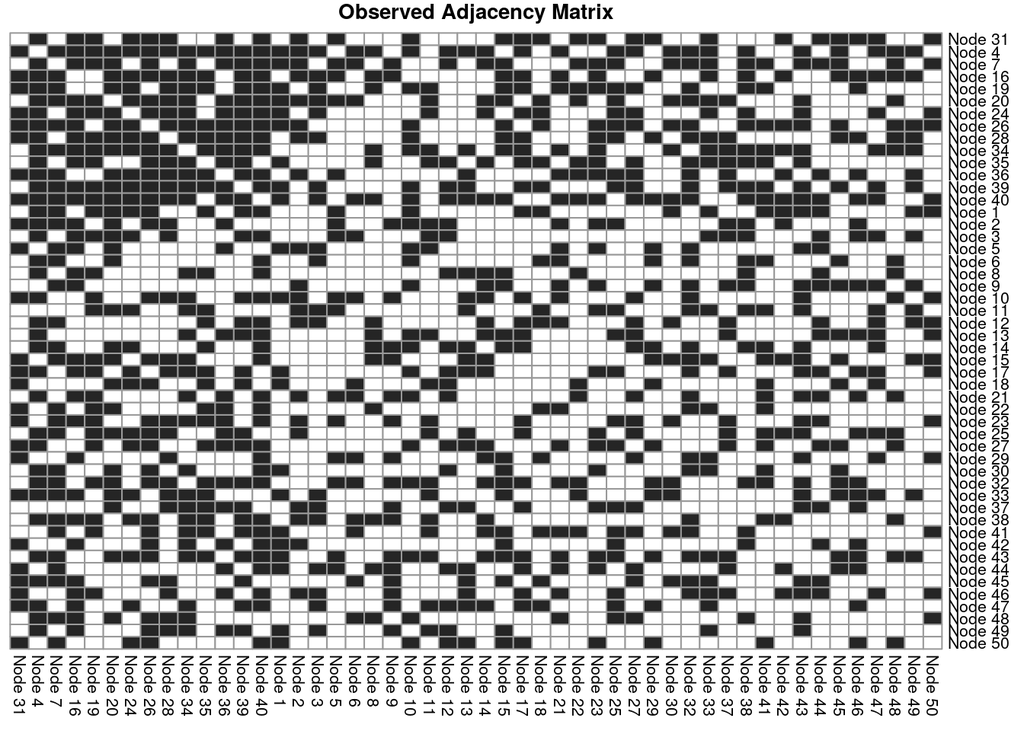

```r
set.seed(100) # 10 gives more clear blocks by chance

# Setup data structure
n.nodes <- 50
n.groups <- 3

# Set hyperparameters
a <- 2
b <- 2


# Simulate group membership
theta <- rdirch(n=1, alpha = rep(1/n.groups, n.groups)) # we could sample alpha from gamma prior too
z <- sample(1:n.groups, size = n.nodes, prob = theta, replace = TRUE)
z.mat <- matrix(0, nrow = n.nodes, ncol = n.groups)
for(i in 1:n.nodes){
  z.mat[i,z[i]] <- 1
}

# Simulate connection probabilities
phi <- matrix(NA, nrow = n.groups, ncol = n.groups) # matrix of group-edge probabilities
phi[upper.tri(phi, diag = TRUE)] <- rbeta(n = n.groups*(n.groups + 1)/2, a, b)
phi[lower.tri(phi, diag = TRUE)] <- t(phi)[lower.tri(phi, diag = TRUE)]

# Compute connection probs for each pair of nodes
pi.mat <- z.mat %*% phi %*% t(z.mat) # ignore diagonal here: no self-edges (loops)
diag(pi.mat) <- NA

# Simulate data
Y <- matrix(NA, nrow = n.nodes, ncol = n.nodes)
Y[upper.tri(Y)] <- rbinom(n.nodes*(n.nodes - 1)/2, 1, pi.mat[upper.tri(pi.mat)])
Y[lower.tri(Y)] <- t(Y)[lower.tri(Y)]
rownames(Y) <- colnames(Y) <- paste0("Node ", 1:n.nodes)

# Might need to add diag to Y to avoid errors
diag(Y) <- 0

# Plot the data
sel <- order(z)
z_sorted <- z[sel]
Y_sorted <- Y[sel, sel]

pheatmap(Y_sorted, cluster_rows = F, cluster_cols = F,
         color=colorRampPalette(brewer.pal(9,"Greys")[c(1,8)])(30),
         main = "Observed Adjacency Matrix",
         fontsize = 8, show_rownames = T, show_colnames = T,
         legend = F)
```

Describe connectivity pattern.

# 1b. Fitting a stochastic block model with NIMBLE

Now we fit the model with NIMBLE.

[output not shown]

```
## Building model
```

```
## Setting data and initial values
```

```
## Running calculate on model
##   [Note] Any error reports that follow may simply reflect missing values in model variables.
```

```
## Checking model sizes and dimensions
```

[output not shown]

```
## Building model
```

```
## Setting data and initial values
```

[output not shown]

```
## Checking model sizes and dimensions
```

```
## Checking model calculations
```

[output not shown]

```
## running chain 1...
```

[output not shown]

```
## running chain 2...
```

[output not shown]

```
## $chain1
##               Mean    Median    St.Dev.    95%CI_low 95%CI_upp
## Z[1]     1.8790000 2.0000000 0.80932936 1.000000e+00 3.0000000
## Z[2]     2.2890000 3.0000000 0.84864551 1.000000e+00 3.0000000
## Z[3]     2.2490000 3.0000000 0.93481168 1.000000e+00 3.0000000
## Z[4]     1.9920000 2.0000000 0.08912881 2.000000e+00 2.0000000
## Z[5]     2.2130000 3.0000000 0.97086228 1.000000e+00 3.0000000
## Z[6]     2.5480000 3.0000000 0.83689689 1.000000e+00 3.0000000
## Z[7]     1.9960000 2.0000000 0.11831314 2.000000e+00 2.0000000
## Z[8]     2.6000000 3.0000000 0.79538207 1.000000e+00 3.0000000
## Z[9]     2.5720000 3.0000000 0.80961193 1.000000e+00 3.0000000
## Z[10]    2.0900000 2.0000000 0.74057305 1.000000e+00 3.0000000
## Z[11]    2.0800000 2.0000000 0.94789161 1.000000e+00 3.0000000
## Z[12]    2.7450000 3.0000000 0.66061442 1.000000e+00 3.0000000
## Z[13]    2.5340000 3.0000000 0.81086466 1.000000e+00 3.0000000
## Z[14]    2.4300000 3.0000000 0.82083724 1.000000e+00 3.0000000
## Z[15]    1.9140000 2.0000000 0.71071028 1.000000e+00 3.0000000
## Z[16]    1.9550000 2.0000000 0.26276233 1.000000e+00 2.0000000
## Z[17]    1.8670000 2.0000000 0.58451061 1.000000e+00 3.0000000
## Z[18]    2.1890000 3.0000000 0.98195888 1.000000e+00 3.0000000
## Z[19]    1.9830000 2.0000000 0.19684956 1.000000e+00 2.0000000
## Z[20]    2.0020000 2.0000000 0.12653858 2.000000e+00 2.0000000
## Z[21]    2.5270000 3.0000000 0.80741744 1.000000e+00 3.0000000
## Z[22]    2.4890000 3.0000000 0.87099807 1.000000e+00 3.0000000
## Z[23]    1.9520000 2.0000000 0.57968270 1.000000e+00 3.0000000
## Z[24]    1.9810000 2.0000000 0.20169204 1.000000e+00 2.0000000
## Z[25]    2.2460000 2.0000000 0.56017658 1.000000e+00 3.0000000
## Z[26]    2.0000000 2.0000000 0.04474374 2.000000e+00 2.0000000
## Z[27]    2.4460000 3.0000000 0.70397413 1.000000e+00 3.0000000
## Z[28]    2.0000000 2.0000000 0.06327720 2.000000e+00 2.0000000
## Z[29]    2.0130000 3.0000000 0.99791123 1.000000e+00 3.0000000
## Z[30]    2.3560000 3.0000000 0.92310136 1.000000e+00 3.0000000
## Z[31]    2.3670000 2.0000000 0.63143464 1.000000e+00 3.0000000
## Z[32]    2.0830000 2.0000000 0.34384477 2.000000e+00 3.0000000
## Z[33]    2.3150000 3.0000000 0.78637993 1.000000e+00 3.0000000
## Z[34]    2.0050000 2.0000000 0.07056897 2.000000e+00 2.0000000
## Z[35]    2.1800000 2.0000000 0.48356368 1.000000e+00 3.0000000
## Z[36]    2.2750000 2.0000000 0.48950446 2.000000e+00 3.0000000
## Z[37]    2.2720000 3.0000000 0.92350900 1.000000e+00 3.0000000
## Z[38]    2.4520000 3.0000000 0.62296395 1.000000e+00 3.0000000
```

[output cut: 112 more lines]

```
## Z[39]    2.0130000 2.0000000 0.11330233 2.000000e+00 2.0000000
## Z[40]    2.0255000 2.0000000 0.16692418 2.000000e+00 3.0000000
## Z[41]    2.5370000 3.0000000 0.71266047 1.000000e+00 3.0000000
## Z[42]    2.3460000 3.0000000 0.93258719 1.000000e+00 3.0000000
## Z[43]    2.0490000 2.0000000 0.22499847 2.000000e+00 3.0000000
## Z[44]    1.8915000 1.0000000 0.98448583 1.000000e+00 3.0000000
## Z[45]    2.4765000 3.0000000 0.83234257 1.000000e+00 3.0000000
## Z[46]    2.1580000 3.0000000 0.90633698 1.000000e+00 3.0000000
## Z[47]    2.1930000 3.0000000 0.94773419 1.000000e+00 3.0000000
## Z[48]    2.6575000 3.0000000 0.70742065 1.000000e+00 3.0000000
## Z[49]    2.4770000 3.0000000 0.85313241 1.000000e+00 3.0000000
## Z[50]    2.0775000 3.0000000 0.98233204 1.000000e+00 3.0000000
## theta[1] 0.1942699 0.1843229 0.16894129 1.438386e-05 0.5172544
## theta[2] 0.4043030 0.3960724 0.11678787 2.034328e-01 0.6477997
## theta[3] 0.4014271 0.4176161 0.17452265 1.645611e-02 0.6977418
```

# 1c. Post processing: create a posterior cluster assignment

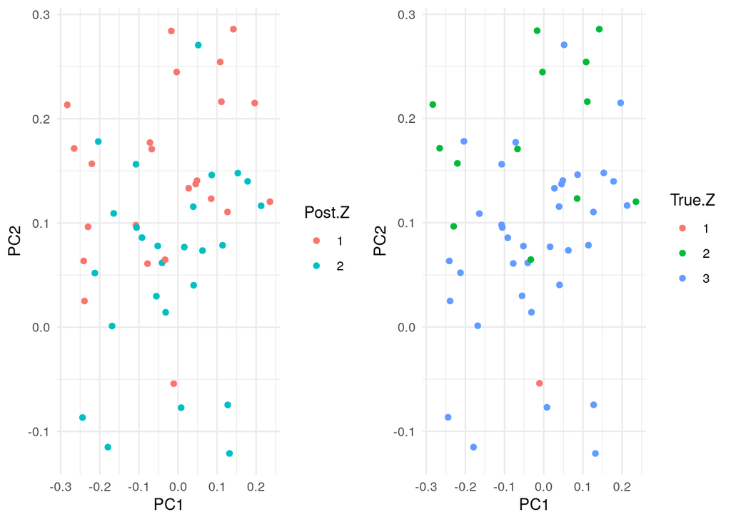

```r
# Extract mcmc  samples
samples <- do.call(rbind, mcmc.out$samples)
z.samples <- samples[, grepl("Z", colnames(samples))]

# Compute posterior similarity matrix
z.psm <- comp.psm(z.samples)

# Find a representative partition of posterior by minimizing VI
z.vi <- minVI(z.psm)
z.cl.post <- z.vi$cl

# Plot posterior clustering
Y.pc <- princomp(Y)$loadings
p1 <- data.frame(PC1 = Y.pc[,1], PC2 = Y.pc[,2], Post.Z = as.factor(z.cl.post)) %>%
  ggplot(aes(x = PC1, y = PC2, color = Post.Z), alpha = 0.25) +
  geom_jitter() +
  theme_minimal()
p2 <- data.frame(PC1 = Y.pc[,1], PC2 = Y.pc[,2], True.Z = as.factor(z)) %>%
  ggplot(aes(x = PC1, y = PC2, color = True.Z)) +
  geom_jitter() +
  theme_minimal()
grid.arrange(p1,p2, nrow = 1)
```

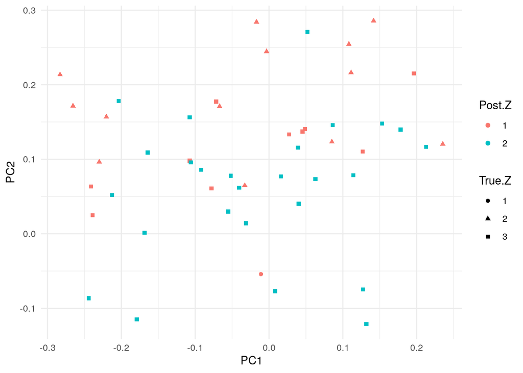

```r
# Another visualization
data.frame(PC1 = Y.pc[,1], PC2 = Y.pc[,2], Post.Z = as.factor(z.cl.post),
           True.Z = as.factor(z)) %>%
  ggplot(aes(x = PC1, y = PC2, color = Post.Z, shape = True.Z), alpha = 0.25) +
  geom_point() +
  theme_minimal()
```

How accurate is our model?

Look at mixing, WAIC, etc.

# PART 2: SIMULATE AND FIT A STOCHASTIC BLOCK MODEL WITH PARTICULAR STRUCTURE

Repeat the exercise above, with the modifications to produce high within-block connectivity and low between block connectivity.

## 2a. Simulation

**Question:** Simulate from a stochastic block model with high within-block connectivity and low between block connectivity. To get started, you might want to explore the parameters of the Beta distribution.

[figure not shown]

```r
# Define range
p = seq(0, 1, length=100)

# Create plot of Beta distribution with various shape parameters
plot(p, dbeta(p, 2, 10), type='l', ylab = 'Density')
lines(p, dbeta(p, 2, 2), col='red')
lines(p, dbeta(p, 5, 2), col='blue')

legend(x = .7, y = 4, legend = c('Beta(1, 10)','Beta(2, 2)','Beta(1,1)'),
       lty=c(1,1,1), col=c('black', 'red', 'blue'))
```

**Answer:** First we simulate from a general stochastic block model with the structure above by placing a separate prior on the diagonal and off-diagonal elements of the $\Phi$ matrix.

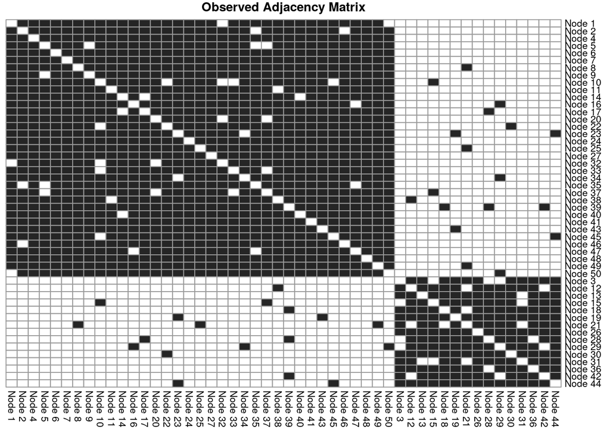

```r
set.seed(10)

# Setup data structure
n.nodes <- 50
n.groups <- 3

# Set hyperparameters
a.bw <- 2
b.bw <- 50
a.wn <- 10
b.wn <- 1

# Simulate group membership
theta <- rdirch(n=1, alpha = rep(1/n.groups, n.groups)) # we could sample alpha from gamma prior too
z <- sample(1:n.groups, size = n.nodes, prob = theta, replace = TRUE)
z.mat <- matrix(0, nrow = n.nodes, ncol = n.groups)
for(i in 1:n.nodes){
  z.mat[i,z[i]] <- 1
}

# Simulate connection probabilities
phi <- matrix(NA, nrow = n.groups, ncol = n.groups) # matrix of group-edge probabilities
phi[upper.tri(phi)] <- rbeta(n = n.groups*(n.groups - 1)/2, a.bw, b.bw)
phi[lower.tri(phi)] <- t(phi)[lower.tri(phi)]
diag(phi) <- rbeta(n = n.groups, a.wn, b.wn)

# Compute connection probs for each pair of nodes
pi.mat <- z.mat %*% phi %*% t(z.mat) # ignore diagonal here
diag(pi.mat) <- NA

# Simulate data
Y <- matrix(NA, nrow = n.nodes, ncol = n.nodes)
Y[upper.tri(Y)] <- rbinom(n.nodes*(n.nodes - 1)/2, 1, pi.mat[upper.tri(pi.mat)])
Y[lower.tri(Y)] <- t(Y)[lower.tri(Y)]
rownames(Y) <- colnames(Y) <- paste0("Node ", 1:n.nodes)

# Might need to add diag to Y to avoid errors
diag(Y) <- 0

# Plot the data
sel <- order(z)
z_sorted <- z[sel]
Y_sorted <- Y[sel, sel]

pheatmap(Y_sorted, cluster_rows = F, cluster_cols = F,
         color=colorRampPalette(brewer.pal(9,"Greys")[c(1,8)])(30),
         main = "Observed Adjacency Matrix",
         fontsize = 8, show_rownames = T, show_colnames = T,
         legend = F)
```